# Trp53cor1 KO vs WT (leg)

```
## Error in file(file, "r"): cannot open the connection
```

This file shows the wt-v-ko comparison for Trp53cor1.

Cuff overview:

```
## CuffSet instance with:
##   2 samples
##   26754 genes
##   77524 isoforms
##   0 TSS
##   23066 CDS
##   0 promoters
##   0 splicing
##   19954 relCDS
```

# QC

## Dispersion

Dispersion plot for genes in cuff: (Overdispersion can lead to innacurate quants)

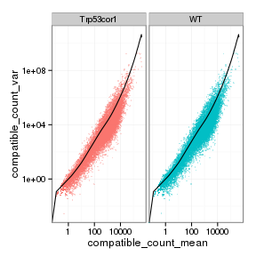

## Cross-replicate variability (fpkmSCVplot)

Differences in CV 2 can result in lower numbers of differentially expressed genes due to a higher degree of variability between replicate fpkm estimates.

Genes:

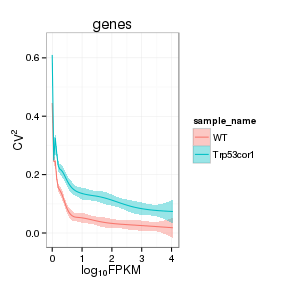

Isoforms:

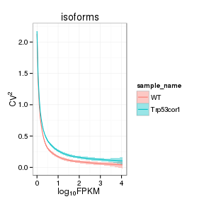

## MvA plot

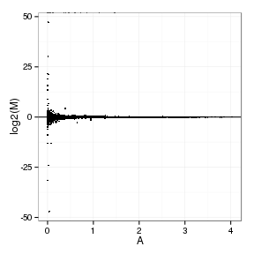

### MvA plot counts

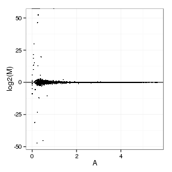

## Scatterplot matrix

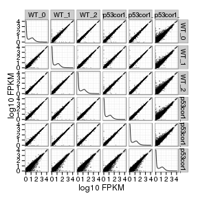

## Distributions

### Boxplots

Boxplot (genes)

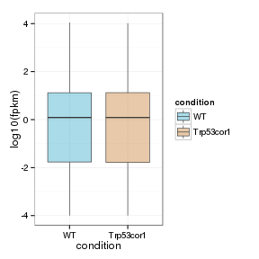

Boxplot (genes, replicates)

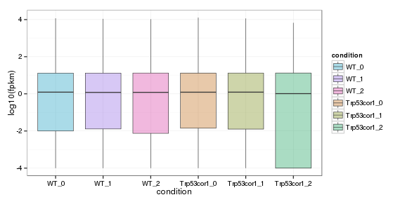

Boxplot (isoforms)

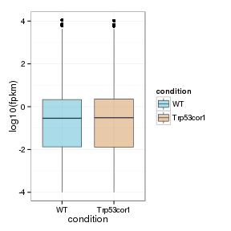

Boxplot (isoforms, replicates)

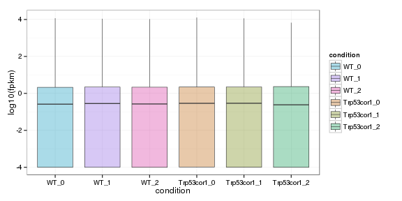

### Density

Density (genes)

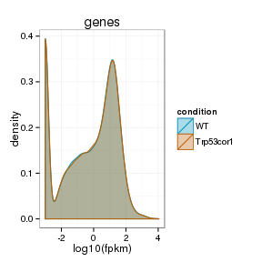

Density (genes, replicates)

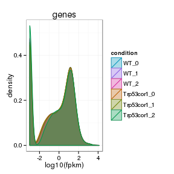

## Clustering

### Replicate Clusters

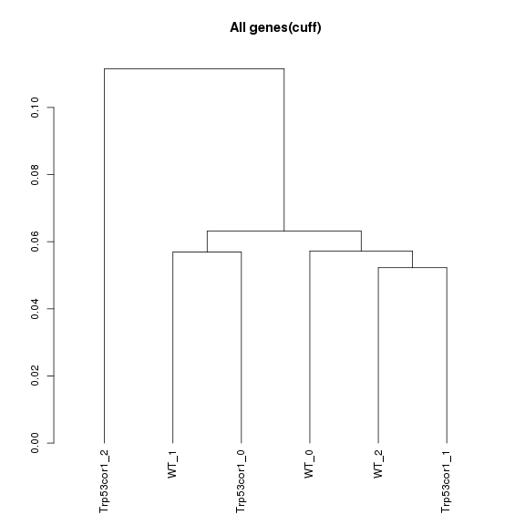

### PCA (genes)

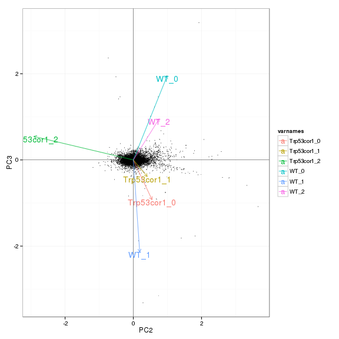

### MDS (genes)

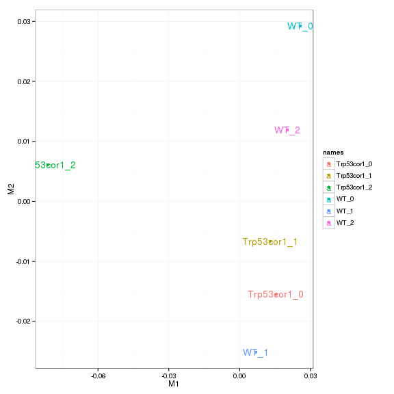

# KO assessment

## Endogenous lncRNA expression

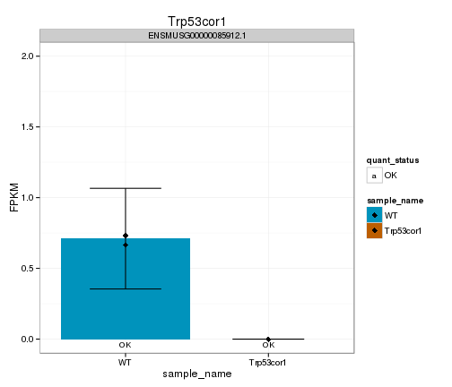

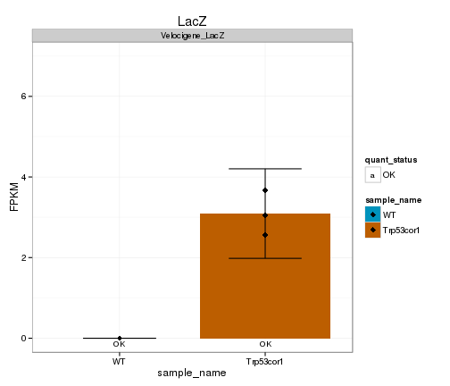

## Digital Genotyping (LacZ vs Endogenous lncRNA and Sex)

Eif2s3y is a y-expressed gene, Xist is an x-expressed gene Expression plot (endogenous linc, lacZ, Y-expressed gene):

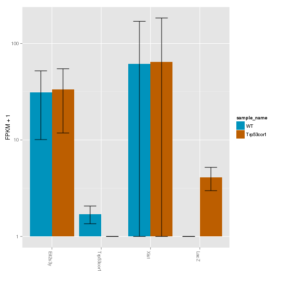

Expression heatmap:

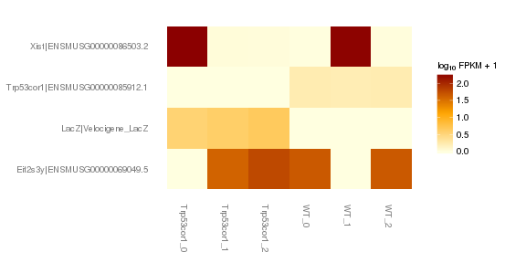

### Track visualization

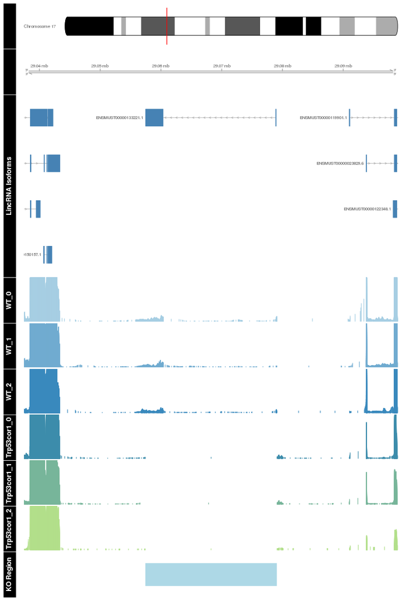

# Differential Analysis

## Differential Genes

There are 103 significantly differentially expressed genes. They are:

|  | geneAnnot$gene_short_name |
| --- | --- |
| 1 | Sox9 |
| 2 | Dynlt1c |
| 3 | Calb2 |
| 4 | Aqp1 |
| 5 | Syngr3 |
| 6 | Iglon5 |
| 7 | Atp1b4 |
| 8 | Matn4 |
| 9 | Aoc3 |
| 10 | Krt10 |
| 11 | Thbs4 |
| 12 | Ldb3 |
| 13 | Sept3 |
| 14 | Cdkn1a |
| 15 | Zscan10 |
| 16 | Glo1 |
| 17 | Prss41 |
| 18 | Tpsab1 |
| 19 | Ankrd1 |
| 20 | Oprk1 |
| 21 | Des |
| 22 | Tnnt2 |
| 23 | Rgs5 |
| 24 | Hsd3b6 |
| 25 | Pla2g2f |
| 26 | Alpl |
| 27 | Htra3 |
| 28 | Spp1 |
| 29 | Ibsp |
| 30 | Dmp1 |

[output cut: 73 more lines]

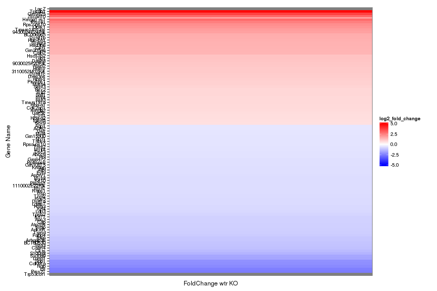

Expression heatmap of sigGenes

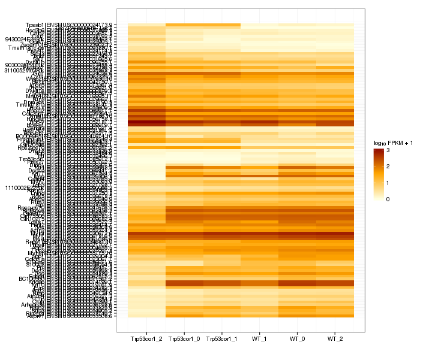

Foldchange heatmap of sigGenes

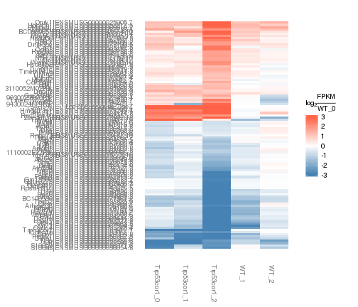

### Expression-level/significance relationship

Scatter plot of significant genes only:

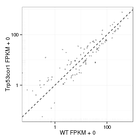

Volcano Plot

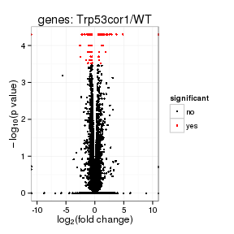

Volcano plot with significant genes only:

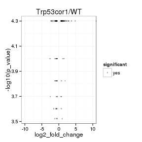

# Gene/Pathway Analysis

Enrichment and zscores are calculated based on expression in KO vs WT (fpkmKO/fpkmWT), so genes that are down regulated in KO are shown in blue, while upregulation is shown in red.

KO/WT Blue = down in KO Red = Up in KO

Biocarta enrichment:

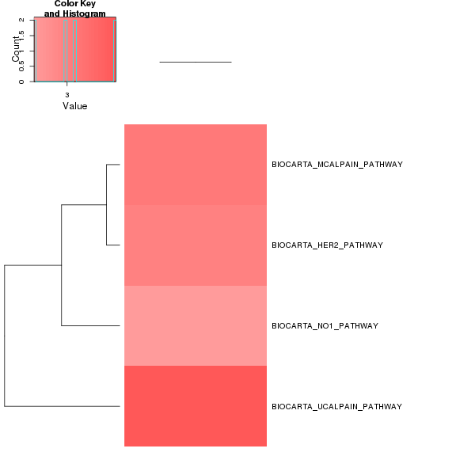

Biocarta zscore:

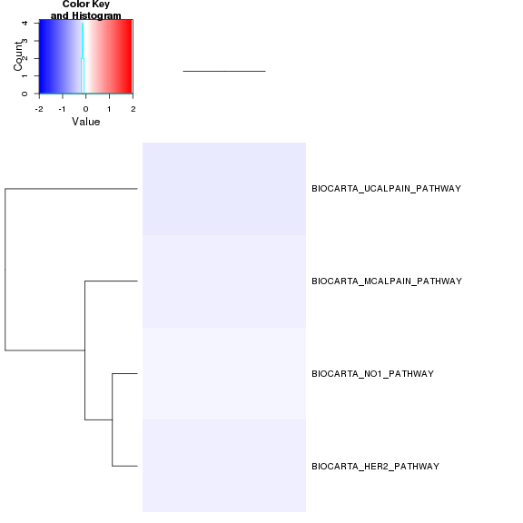

Reactome enrichment:

```
## Error in x_ordered[1:50, ]: subscript out of bounds
```

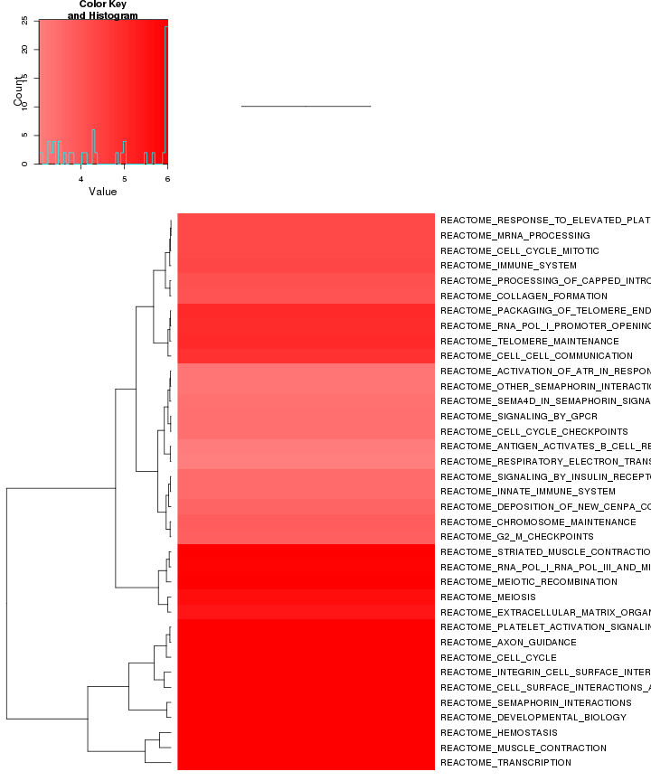

Reactome zscore:

```
## Error in x_ordered[1:50, ]: subscript out of bounds
```

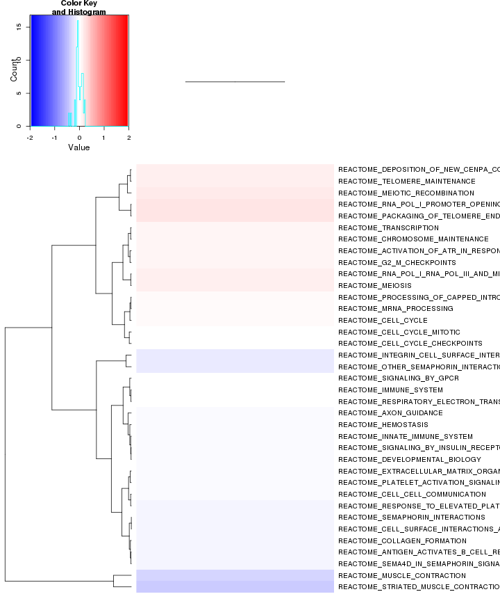

p53 enrichment:

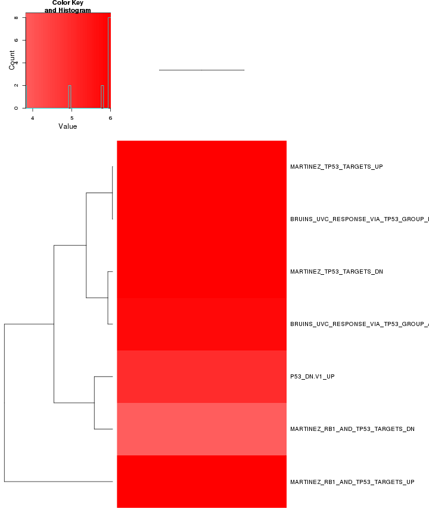

p53 zscore:

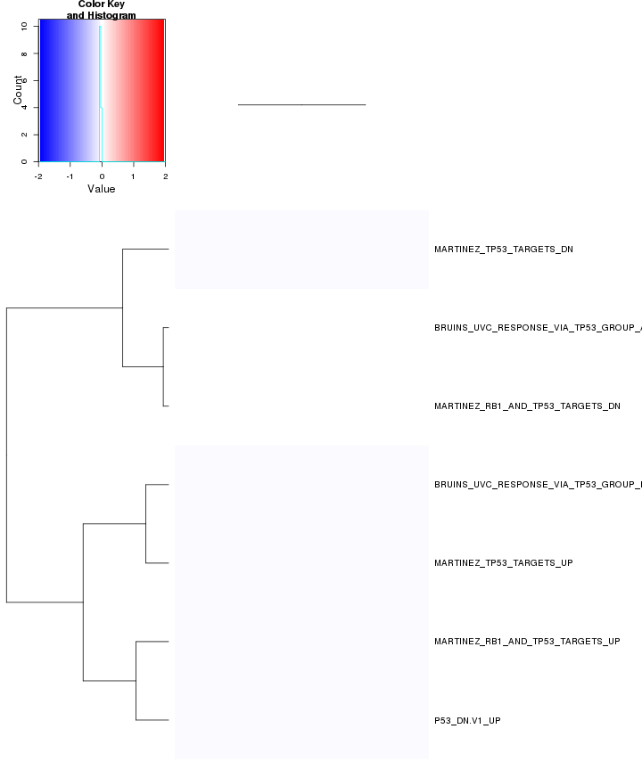

## GO enrichment

Cluster profiler used to call enichments of significantly differentially regulated genes that map to Entrez IDs.

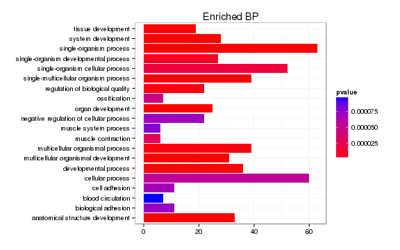

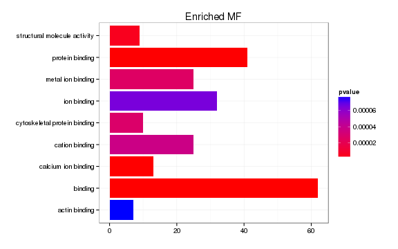

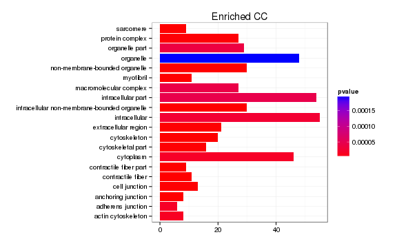

```
## Error in unit(tic_pos.c, "mm"): 'x' and 'units' must have length > 0
```

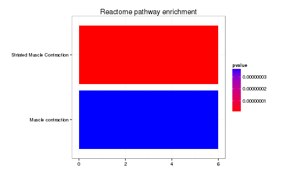

# Cis vs Trans (locally)

log2 Foldchange and test statistic are calculated with the ratio of fpkm(KO)/fpkm(WT), thus the test_stat is positive if a gene is higher in the KO and negative if a gene has lower expression in the KO

The pvalue for genes significantly regulated in a region this size is: 0.02

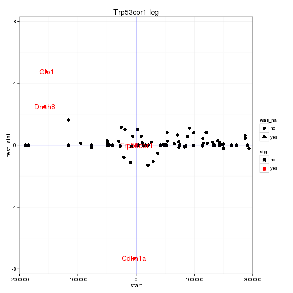

# Notes

## Samples used are:

|  | 11 |
| --- | --- |
| 1 | JR878 |
| 2 | JR880 |
| 3 | JR881 |
| 4 | JR882 |
| 5 | JR883 |
| 6 | lincp21_Leg_KO4 |

## Replicates

|  | file | sample_name | replicate | rep_name | total_mass | norm_mass | internal_scale | external_scale |
| --- | --- | --- | --- | --- | --- | --- | --- | --- |
| 1 | /n/rinn_data1/users/agroff/seq/OtherMice/Diana/lincP21/quants/JR878/abundances.cxb | WT | 0 | WT_0 | 48224900.00 | 44016600.00 | 1.07 | 1.00 |
| 2 | /n/rinn_data1/users/agroff/seq/OtherMice/Diana/lincP21/quants/JR880/abundances.cxb | WT | 1 | WT_1 | 52725300.00 | 44016600.00 | 1.19 | 1.00 |
| 3 | /n/rinn_data1/users/agroff/seq/OtherMice/Diana/lincP21/quants/JR881/abundances.cxb | WT | 2 | WT_2 | 43230900.00 | 44016600.00 | 0.98 | 1.00 |
| 4 | /n/rinn_data1/users/agroff/seq/OtherMice/Diana/lincP21/quants/JR882/abundances.cxb | Trp53cor1 | 0 | Trp53cor1_0 | 61630100.00 | 44016600.00 | 1.40 | 1.00 |
| 5 | /n/rinn_data1/users/agroff/seq/OtherMice/Diana/lincP21/quants/JR883/abundances.cxb | Trp53cor1 | 1 | Trp53cor1_1 | 53017900.00 | 44016600.00 | 1.20 | 1.00 |
| 6 | /n/rinn_data1/users/agroff/seq/OtherMice/Diana/lincP21/quants/lincp21_Leg_KO4/abundances.cxb | Trp53cor1 | 2 | Trp53cor1_2 | 20607100.00 | 44016600.00 | 0.48 | 1.00 |

## Run Info

```
##           param
## 1      cmd_line
## 2       version
## 3  SVN_revision
## 4 boost_version
## 5        genome
##                                                                                                                                                                                                                                                                                                          …
## 1 cuffdiff -p 10 -L WT,Trp53cor1 -o /n/rinn_data1/users/agroff/seq/OtherMice/Diana/lincP21/diff/Trp53cor1_E14.5_Leg_b0331 /n/rinn_data1/seq/lgoff/Projects/BrainMap/data/annotation/mm10_gencode_vM2_with_lncRNAs_and_LacZ.gtf /n/rinn_data1/users/agroff/seq/OtherMice/Diana/lincP21/quants/JR878/abunda…
## 2                                                                                                                                                                                                                                                                                                        …
## 3                                                                                                                                                                                                                                                                                                        …
## 4                                                                                                                                                                                                                                                                                                        …
## 5                                                                                                                                                                                                                                                                                                        …
```